# DEEP LEARNING CA1 PART A: CONVOLUTIONAL NEURAL NETWORK

## Improved Model 2 Prediction

```python
from sklearn.metrics import accuracy_score
```

```python
predict= model_improved2.predict(X_test)
```

```python
eval_result = model_improved2.evaluate(X_test, y_test)
print("[test loss, test accuracy]:", eval_result)
```

```
[test loss, test accuracy]: [0.2139723151922226, 0.9405999779701233]
```

```python
import sklearn.metrics as metrics
print(metrics.classification_report(data['Class'], pred_labels, target_names=class_names))
```

```
              precision    recall  f1-score   support

 T-shirt/top       0.90      0.90      0.90      1000
     Trouser       0.99      0.99      0.99      1000
    Pullover       0.91      0.92      0.92      1000
       Dress       0.94      0.96      0.95      1000
        Coat       0.89      0.92      0.91      1000
      Sandal       0.99      0.99      0.99      1000
       Shirt       0.84      0.80      0.82      1000
     Sneaker       0.97      0.98      0.97      1000
         Bag       0.99      0.99      0.99      1000
  Ankle boot       0.98      0.97      0.98      1000

    accuracy                           0.94     10000
   macro avg       0.94      0.94      0.94     10000
weighted avg       0.94      0.94      0.94     10000
```

Correct prediction labels are blue and incorrect prediction labels are red. The number gives the percent (out of 100) for the predicted label.

Plotting several images with their predictions. Correct prediction labels are blue and incorrect prediction labels are red. The number gives the percent (out of 100) for the predicted label. Note that it can be wrong even when very confident.

[figure not shown]

```python
# Plot the first X test images, their predicted label, and the true label
# Color correct predictions in blue, incorrect predictions in red
num_rows = 5
num_cols = 3
num_images = num_rows*num_cols
plt.figure(figsize=(2*2*num_cols, 2*num_rows))
for i in range(num_images):
    plt.subplot(num_rows, 2*num_cols, 2*i+1)
    plot_image(i, predictions, y_test, X_test)
    plt.subplot(num_rows, 2*num_cols, 2*i+2)
    plot_value_array(i, predictions, y_test)
plt.show()
```

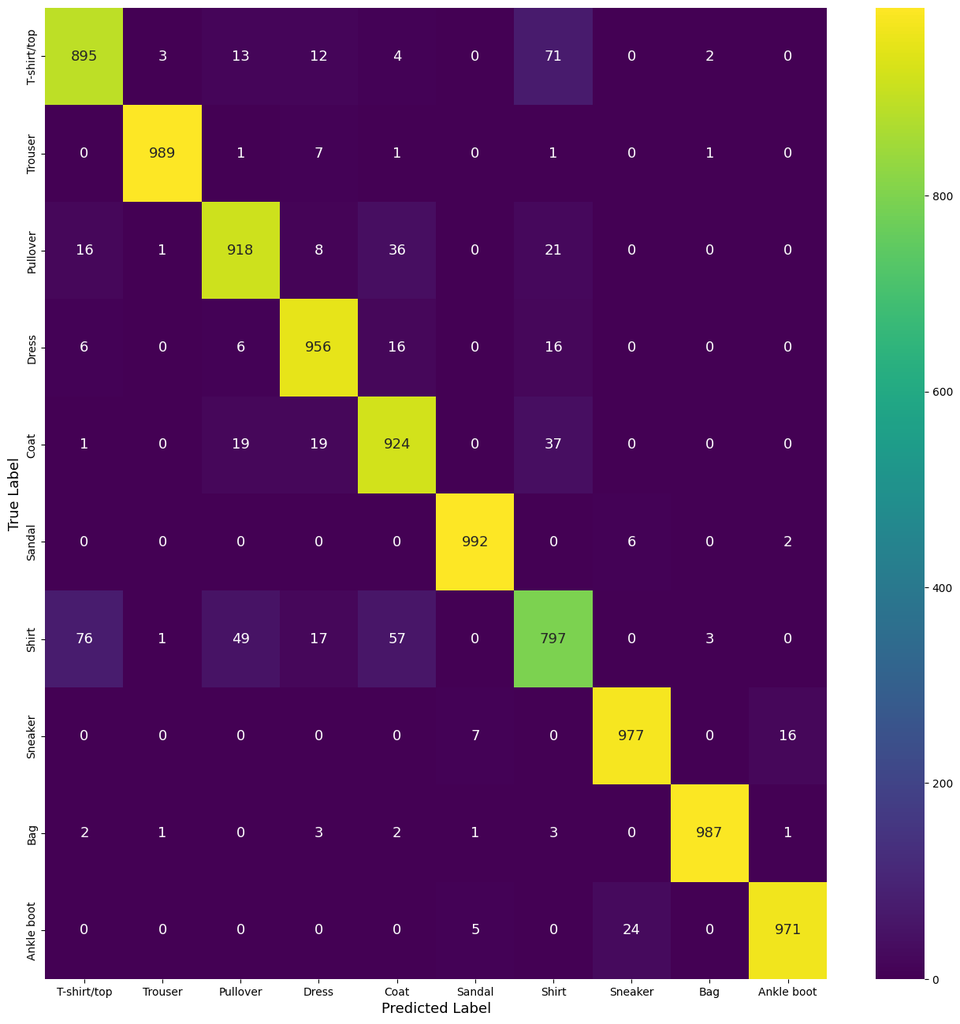

```python
import seaborn as sns
prob_confusion_matrix = metrics.confusion_matrix(data['Class'], pred_labels)

plt.figure(figsize=(16,16))

sns.heatmap(prob_confusion_matrix, annot=True, fmt="d", cmap = 'viridis'
           , xticklabels = class_names, yticklabels = class_names, annot_kws={'size': 13})

plt.xlabel("Predicted Label", fontsize= 13)
plt.ylabel("True Label", fontsize= 13)

plt.show()
```

## Improved Model 2 Prediction AFTER Hypertuning

```python
predict= model.predict(X_test)
```

```python
eval_result = model.evaluate(X_test, y_test)
print("[test loss, test accuracy]:", eval_result)
```

```
[test loss, test accuracy]: [0.3801257610321045, 0.9387000203132629]
```

```python
import sklearn.metrics as metrics
print(metrics.classification_report(data['Class'], pred_labels, target_names=class_names))
```

```
              precision    recall  f1-score   support

 T-shirt/top       0.90      0.88      0.89      1000
     Trouser       1.00      0.99      0.99      1000
    Pullover       0.89      0.92      0.91      1000
       Dress       0.93      0.95      0.94      1000
        Coat       0.90      0.91      0.91      1000
      Sandal       0.99      0.99      0.99      1000
       Shirt       0.83      0.81      0.82      1000
     Sneaker       0.97      0.98      0.97      1000
         Bag       0.99      0.99      0.99      1000
  Ankle boot       0.98      0.97      0.98      1000

    accuracy                           0.94     10000
   macro avg       0.94      0.94      0.94     10000
weighted avg       0.94      0.94      0.94     10000
```

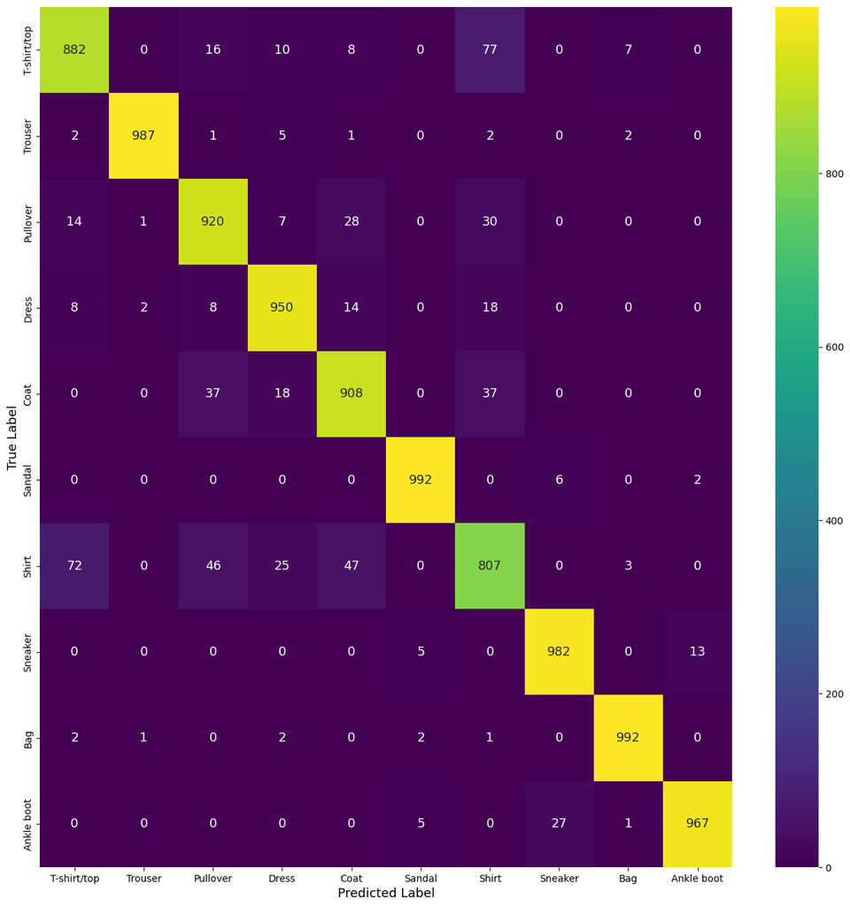

```python
import seaborn as sns
prob_confusion_matrix = metrics.confusion_matrix(data['Class'], pred_labels)

plt.figure(figsize=(16,16))

sns.heatmap(prob_confusion_matrix, annot=True, fmt="d", cmap = 'viridis'
           , xticklabels = class_names, yticklabels = class_names, annot_kws={'size': 13})

plt.xlabel("Predicted Label", fontsize= 13)
plt.ylabel("True Label", fontsize= 13)

plt.show()
```

Save Improved model 1

```python
tf.keras.models.save_model(
    model_improved1,
    "model_improved1.h5",
    overwrite=True,
    include_optimizer=True,
    save_format=None,
    signatures=None,
    options=None,
    save_traces=True
)
```

Save Improved model 2

```python
tf.keras.models.save_model(
    model_improved2,
    "model_improved2.h5",
    overwrite=True,
    include_optimizer=True,
    save_format=None,
    signatures=None,
    options=None,
    save_traces=True
)
```

Save hypertuned model

```python
tf.keras.models.save_model(
    model,
    "tuned_model.h5",
    overwrite=True,
    include_optimizer=True,
    save_format=None,
    signatures=None,
    options=None,
    save_traces=True
)
```